# Homework #8 Math 160

Ethan Ashby

Due: 31 Mar, 2021

1. Create solutions using `:::: {.solution}` and `::::` in the .Rmd file.
2. If the .css file is not working for you, type out the Problem headings using `# Problem 1`, `# Solution`, `# Problem 2`, and so on.
3. Knit to an .html file.
4. Print out the .html file inside a browser (such as Chrome or Safari) to a .pdf file.
5. Upload the .pdf file to Gradescope.
6. Mark the pages that your questions are on.
7. Be sure to box your answers with the `\boxed{put in box}` $\LaTeX$ command.
8. Be sure to give nonintegral answers to four significant digits.

Consider the following simple symmetric random walk that takes as input $x \in \{1, 2, 3, 4, 5\}$, $m \in \{-1, 1\}$, and returns $x$ if $x + m \notin \{1, \ldots, 5\}$, and $x + m$ otherwise.

```r
step_ssrwwprb <- function(x, m) {
  y <- x + m
  if (y < 1 | y > 5)
    return(x)
  else
    return(y)
}
```

Prove that this update is monotonic by showing that for $x \leq w$ and $m \in \{-1, 1\}$, it holds that
$$\texttt{step_ssrwwprb(x, m)} \leq \texttt{step_ssrwwprb(w, m)}.$$

(Hint: consider cases $y = 0$, $z = 6$, and $(1 \leq y) \wedge (z \leq 5)$.)

We want to prove that the update is monotonic by showing that for $x \leq w$ and $m \in \{-1, 1\}$, it holds that $\texttt{step_ssrwwprb(x, m)} \leq \texttt{step_ssrwwprb(w, m)}$.

We’ll prove this statement by breaking up into cases.

Case (i): suppose $x,w \in \{2,3,4\}$. Then for $m=-1$, $\texttt{step_ssrwwprb(x, m)}=x-1$ and $\texttt{step_ssrwwprb(w, m)}=w-1$. Since $x \leq w$, $x-1 \leq w-1 \Rightarrow \texttt{step_ssrwwprb(x, m)} \leq \texttt{step_ssrwwprb(w, m)}$. The same holds for if $m=+1$, $\texttt{step_ssrwwprb(x, m)}=x+1$ and $\texttt{step_ssrwwprb(w, m)}=w+1$. Since $x \leq w$, $x+1 \leq w+1 \Rightarrow \texttt{step_ssrwwprb(x, m)} \leq \texttt{step_ssrwwprb(w, m)}$. We’ve proved the desired condition.

Case (ii): suppose $x=1$ and $w \in \{1, \ldots , 5\}$. Then for $m=-1$, $\texttt{step_ssrwwprb(x, m)}=1$. Since the output of the step function must be in $\{1, \ldots, 5\}$, $1 \leq \texttt{step_ssrwwprb(w, m)}$. Thus, we conclude that $1=\texttt{step_ssrwwprb(x, m)} \leq \texttt{step_ssrwwprb(w, m)}$. For $x=1$ and $m=+1$, $\texttt{step_ssrwwprb(x, m)}=2$. Since $1 \leq w \Rightarrow 2 \leq w+1 \Rightarrow \texttt{step_ssrwwprb(x, m)} \leq \texttt{step_ssrwwprb(w, m)}$. We’ve shown the desired condition.

Case (iii) suppose $w=5$ and $x \in \{1, \ldots , 5\}$. Then for $m=-1$, $w-1=\texttt{step_ssrwwprb(w, m)}=4$. Since $x \leq w$, then $x-1 \leq w-1$ so necessarily $\texttt{step_ssrwwprb(x, m)} \leq \texttt{step_ssrwwprb(w, m)}$. In the case where $m=+1$, $\texttt{step_ssrwwprb(w, m)}=5$. But since $\texttt{step_ssrwwprb(x, m)} \in \{1, \ldots, 5\}$, then by necessity $\texttt{step_ssrwwprb(x, m)} \leq \texttt{step_ssrwwprb(w, m)}=5$.

Thus, in all cases, we showed that $x \leq w$ implies $\texttt{step_ssrwwprb(x, m)} \leq \texttt{step_ssrwwprb(w, m)}$. So we’ve proved monotonicity.

Continuing the last problem, run $\texttt{step_ssrwwprb}$ forward from state 1 and state 5 for $t$ steps.

1. Plot the results of your run for $t = 10$.
2. Plot the results of your run for $t = 100$.
1. Run 10 steps

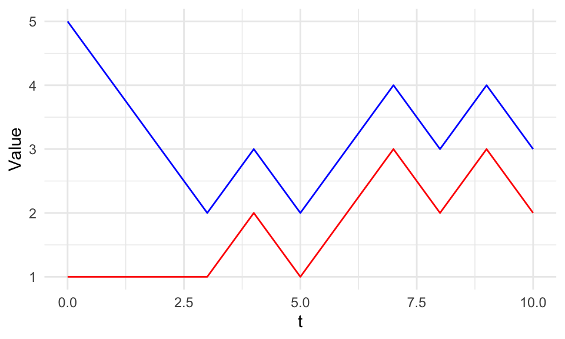

```r
set.seed(1234567)
run_twochains<-function(steps){
  moves<-2*(runif(steps)<0.5)-1
  x1_vec<-c(1)
  for(i in 1:steps)
    x1_vec<-c(x1_vec, step_ssrwwprb(x1_vec[i], moves[i]))
  x2_vec<-c(5)
  for(i in 1:steps)
    x2_vec<-c(x2_vec, step_ssrwwprb(x2_vec[i], moves[i]))
  return(cbind(t=0:steps, lower=x1_vec, upper=x2_vec) %>% as.data.frame())
}

run_twochains(steps=10) %>% ggplot()+geom_line(aes(x=t, y=lower), color="red")+geom_line(aes(x=t, y=upper), color="blue")+theme_minimal()+ylab("Value")
```

2. Run 100 steps

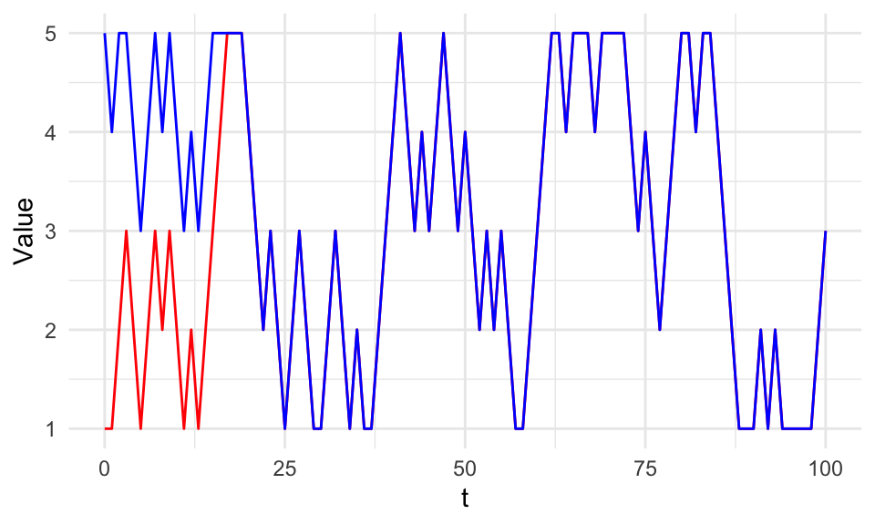

```r
run_twochains(steps=100) %>% ggplot()+geom_line(aes(x=t, y=lower), color="red")+geom_line(aes(x=t, y=upper), color="blue")+theme_minimal()+ylab("Value")
```

Note that the two curves couple after 20 time steps or so!

Consider the following product slice sampler with stationary distribution density proportional to
$$g_X(x) = \sin(x) \cos(x)^2 \mathbb{I}(x \in [0, \tau / 4]).$$

```r
step_trig_pss <- function(x, u) {
  y <- u[1:3] * c(sin(x), cos(x), cos(x))
  x <- u[4] * (min(acos(y[2:3])) - asin(y[1])) + asin(y[1])
  return(x)
}
```

Prove directly that for $x \leq w$ and $u \in [0, 1]^4$ that $\texttt{step_trig_pss(x, u)} \leq \texttt{step_trig_pss(w, u)}$.

Say $x \leq w$. Then define $y_1=u_1 \sin(x)$, $y_2 = u_2 \cos(x)$, $y_3=u_3 \cos(x)$. Similarly, let $z_1=u_1 \sin(w)$, $z_2 = u_2 \cos(w)$, $z_3=u_3 \cos(w)$. In this case, $y_1 \leq z_1$, $y_2 \geq z_2$, $y_3 \geq z_3$ (because sine is an increasing function over $[0, \tau/4]$ and cosine is decreasing over $[0, \tau/4]$).

Note that
$$x=u_4 \cdot (\min(\arccos(y_2), \arccos(y_3)) - \arcsin(y_1)) + \arcsin(y_1)$$
.
$$x=u_4 \min(\arccos(y_2), \arccos(y_3)) + (1-u_4) \arcsin(y_1)$$
.

Now $y_1 \leq z_1 \Rightarrow \arcsin(y_1) \leq \arcsin(z_1)$ (b/c arcsine is increasing function). $y_2 \geq z_2 \Rightarrow \arccos(y_2) \leq \arccos(z_2)$ (b/c arccos is decreasing function). $y_3 \geq z_3 \Rightarrow \arccos(y_3) \leq \arccos(z_3)$ (b/c arccos is decreasing function). This implies that:
$$u_4 \min(\arccos(y_2), \arccos(y_3)) + (1-u_4) \arcsin(y_1) \leq u_4 \min(\arccos(z_2), \arccos(z_3)) + (1-u_4) \arcsin(z_1)$$
which implies
$$\texttt{step_trig_pss(x, u)} \leq \texttt{step_trig_pss(w, u)}$$

Continuing the last problem, start with $X_0 = 0$ and $W_0 = 1$ and find $X_{10}$ and $W_{10}$ using the same random numbers. Repeat this $1000$ times and report the average of the difference $W_{10} - X_{10}$ as $a \pm b$.

```r
set.seed(1234567)
run_chains_p4<-function(steps){
  #uniforms
  us<-replicate(4, runif(steps))

  #lower chain
  x=0
  #upper chain
  w=1
  for(i in 1:steps){
    x<-step_trig_pss(x, us[i,])
    w<-step_trig_pss(w, us[i,])
  }
  #return difference in w and x
  return(w-x)
}

diffs<-replicate(1000, run_chains_p4(10))

tibble(
  mean=mean(diffs),
  se=sd(diffs)/sqrt(length(diffs))
) %>% kable()
```

| mean | se |
| --- | --- |
| 0.0004074 | 3.78e-05 |

The estimate of the difference $W_{10} - X_{10}$ is $\boxed{0.000407 \pm 0.000038}$

Continuing the last problem, use $W_{25}$ and $X_{25}$ to estimate the mean of a draw from the density $\sin(x) \cos(x)^2 \mathbb{I}(x \in [0, \tau / 4])$. Report the upper bound and lower bound on the estimate.

```r
set.seed(1234567)
run_chains_p5<-function(steps){
  #uniforms
  us<-replicate(4, runif(steps))
  #lower chain
  x=0
  #upper chain
  w=1
  for(i in 1:steps){
    x<-step_trig_pss(x, us[i,])
    w<-step_trig_pss(w, us[i,])
  }
  #return difference in w and x
  return(c(x, w))
}

res<-replicate(1000, run_chains_p5(steps=25))

tibble(
  est_mean_lower=mean(res[1,]),
  est_sd_lower= sd(res[1,])/sqrt(length(res[1,])),
  est_mean_upper=mean(res[2,]),
  est_sd_upper=sd(res[2,])/sqrt(length(res[2,]))
) %>% kable()
```

| est_mean_lower | est_sd_lower | est_mean_upper | est_sd_upper |
| --- | --- | --- | --- |
| 0.6789412 | 0.0092827 | 0.6789412 | 0.0092827 |

My estimate for the upper and lower bound of the estimate are $[0.6789 \pm 0.0093, 0.6789 \pm 0.0093]$.

Continuing the last problem, use 1000 replications of states $X_{5}$ and $W_{5}$ states to give an upper and lower bound on an estimate of $\mathbb{P}(A \leq 0.3)$ where $A$ is a draw from the density $\sin(x) \cos(x)^2 \mathbb{I}(x \in [0, \tau / 4])$.

```r
set.seed(1234567)
chain_next<-function(steps){
  datasteps <- steps
  a <- 0
  b <- 1
  res<-rep(0, datasteps)
  u1 <- matrix(runif(4 * datasteps), ncol = 4)
  for (i in 1:datasteps) {
    a <- step_trig_pss(a, u1[i,])
    b <- step_trig_pss(b, u1[i,])
    #outputs 1 if interval is squarely below 0.3, outputs 0 if interval is squarely above 0.3, -1 if maybe
    res[i]<-(b<=0.3) - (a < 0.3)*(b > 0.3)
  }
  #u2 <- matrix(runif(4 * datasteps), ncol = 4)
  #for (i in 1:steps) {
  #  a <- step_trig_pss(a, u2[i,])
  #  b <- step_trig_pss(b, u2[i,])
  #  res[i] <- (b <= 0.3) - (a < 0.3) * (b > 0.3)
  #  }
  return(res)
}

res<-replicate(1000, chain_next(steps=5)[5])

tibble(
  est_mean_a=mean(res==1),
  est_sd_a=sd(res==1)/sqrt(length(res)),
  est_mean_b=mean(res==1 | res==-1),
  est_sd_b=sd(res==1 | res==-1)/sqrt(length(res))
) %>% kable()
```

| est_mean_a | est_sd_a | est_mean_b | est_sd_b |
| --- | --- | --- | --- |
| 0.125 | 0.0104635 | 0.134 | 0.0107778 |

Continuing the last problem, use $X_{11}, \ldots, X_{20}$ and $W_{11}, \ldots, W_{20}$ to estimate $\mathbb{P}(A \leq 0.3)$. Replicate the result 1000 times to get the estimate.

```r
set.seed(1234567)
chain_next<-function(steps){
  datasteps <- steps
  a <- 0
  b <- 1
  res <- rep(0, datasteps)
  u2 <- matrix(runif(4 * datasteps), ncol = 4)
  for (i in 1:steps) {
    a <- step_trig_pss(a, u2[i,])
    b <- step_trig_pss(b, u2[i,])
    res[i] <- (b <= 0.3) - (a < 0.3) * (b > 0.3)
    }
  return(res)
}

res<-replicate(1000, chain_next(steps=20)[11:20])

tibble(
  mean=mean(res),
  se=sd(res)/sqrt(length(res))
) %>% kable()
```

| mean | se |
| --- | --- |
| 0.1305 | 0.0033687 |

My estimate of $\mathbb{P}(A \leq 0.3) = \boxed{0.1305 \pm 0.0034}$.

Consider a simple nonsymmetric random walk with partially reflecting boundaries on $\Omega = \{1, \ldots, 5 \}$.

```r
step_srwwprb <- function(x, m) {
  y <- x + m
  if (y < 1 | y > 5)
    return(x)
  else
    return(y)
}
```

After 10000 steps of burnin, take 10000 steps in this chain with $\mathbb{P}(m = -1) = 0.4,\ \mathbb{P}(m = 1) = 0.6$ and plot a histogram of the states obtained.

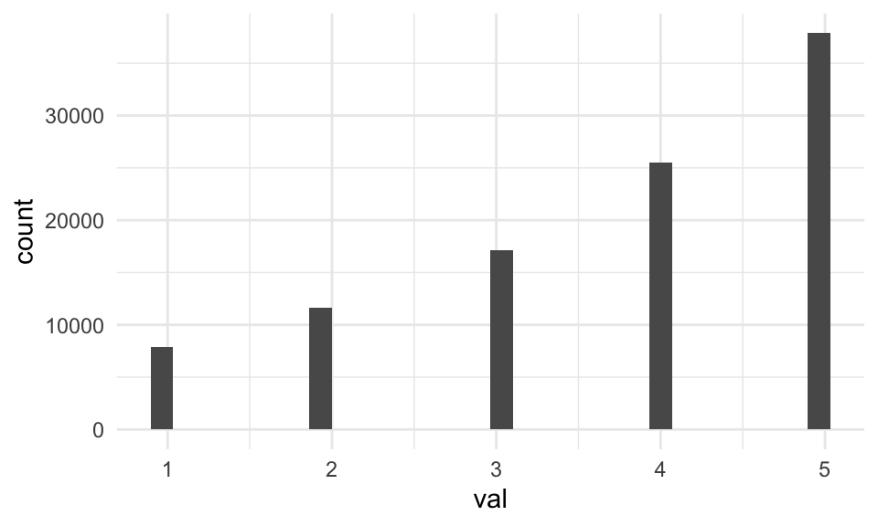

```r
set.seed(1234567)
run_chain_p8<-function(steps){
  burnin=steps
  datasteps=steps
  m1<-2*(runif(burnin)<0.6)-1
  x=1
  for(i in 1:burnin){
    x<-step_srwwprb(x, m1[i])
  }

  res<-rep(0, datasteps)
  m2<-2*(runif(datasteps)<0.6)-1
  for(i in 1:datasteps){
    x<-step_srwwprb(x, m2[i])
    res[i]<-x
  }
  return(res)
}

res<-run_chain_p8(steps=10^5)
data.frame(val=res) %>% ggplot()+geom_histogram(aes(x=val))+theme_minimal()
```

Using the chain from the previous problem as a proposal chain, build a Metropolis-Hastings update for the unnormalized density
$$h_X(i) = i \mathbb{I}(i \in \{1, \ldots, 5\}).$$

After 10000 steps of burnin, take 10000 steps in this chain with $\mathbb{P}(m = -1) = 0.4,\ \mathbb{P}(m = 1) = 0.6$ and plot a histogram of the states obtained.

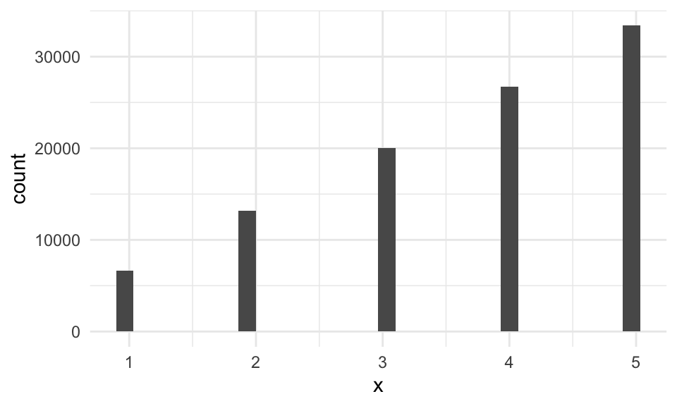

```r
set.seed(1234567)
#step function
step_p8<-function(x, m, u){
  y<-x+m
  if(u <= (y*(y>0)*(y<6)/x))
    return(y)
  else
    return(x)
}

chain_p8<- function(steps){
  burnin <- steps
  datasteps <- steps
  x <- 3
  res <- rep(0, datasteps)

  #burnin
  m1 <- 2 * (runif(burnin) < 0.6) - 1
  u1 <- runif(burnin)
  for (i in 1:burnin) {
    x <- step_p8(x, m1[i], u1[i])
  }

  m2 <- 2 * (runif(burnin) < 0.5) - 1
  u2 <- runif(burnin)
  for (i in 1:datasteps) {
    x <- step_p8(x, m2[i], u2[i])
    res[i] <- x
  }
  return(res)
}

tibble(
  x=chain_p8(steps=10^5)
) %>% ggplot()+geom_histogram(aes(x=x))+theme_minimal()
```

Consider the unnormalized density
$$g_X(s) = \exp(-s^{3 / 2}) \mathbb{I}(s \geq 0).$$

1. Write code for a Metropolis-Hastings step with proposal move $Y = X + M$ where $M \sim \textsf{Unif}([-2, 1])$.
2. Use your code with 10 replications of 1000 burnin and data gathering steps to estimate $\mathbb{E}[X]$. Report your result as $a \pm b$.

```r
step_p10<-function(x, m, u){
  y<-x+m
  if(u <= (y>=0)*exp(-(y*(y>=0))^(3/2))/(exp(-x^(3/2))))
    return(y)
  else
    return(x)
}
```

```r
set.seed(1234567)
chain_p10<-function(steps){
  burnin=steps
  datasteps=steps
  m1<-3*runif(burnin)-2
  u1<-runif(burnin)
  x<-0
  for(i in 1:burnin){
    x<-step_p10(x, m1[i], u1[i])
  }

  res<-rep(0, datasteps)
  m2<-3*runif(burnin)-2
  u2<-runif(burnin)
  for(i in 1:datasteps){
    x<-step_p10(x, m2[i], u2[i])
    res[i]<-x
  }

  return(res)
}

res<-replicate(10, mean(chain_p10(steps=1000)))

tibble(
  mean=mean(res),
  se=sd(res)/sqrt(length(res))
) %>% kable()
```

| mean | se |
| --- | --- |
| 0.5271786 | 0.0089167 |

My estimate of $\mathbb{E}[X]=\boxed{0.5272 \pm 0.0090}$.